# **The Shadow of Occupation:** Opportunism and Preference Revelation under Foreign Invasion

NYU AD x EUI 2026, Florence

Frederik  
Thieme

frederik.thieme@hu-berlin.de

Humboldt-Universität zu Berlin

Salma  
Mahamed

sma.egb@cbs.dk

Copenhagen Business School

May 19, 2026

## Motivation

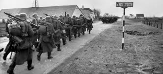

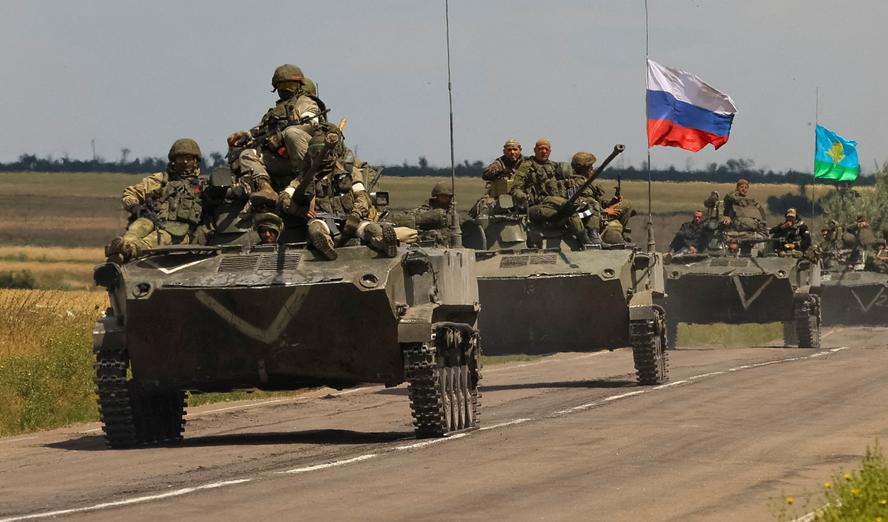

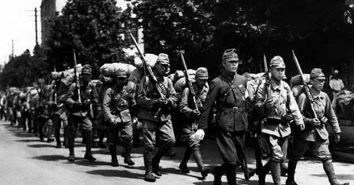

[figure not shown]

## Collaboration under Military Occupation

- ❓ `Research Question`
  - (How) Does military occupation impact political support?
- `occupier's problem` (Hechter and Vidal-Aparicio 2011)
  - limited coercive reach, weak local information
  - necessity of domestic intermediaries for administration, policing, intelligence
- `occupier's dilemma` (Hickman 2017):
  - reliance on local sympathizers with potentially instrumental motives
  - contempt or backlash among the broader population

## Previous Research

- German occupation in WWII: patterns of resistance and long-term legacies (Cagé et al. 2023; Fontana, Nannicini, and Tabellini 2023; Fouka and Voth 2023)
- Danish case: military collaboration and post-war preferences (Aaskoven 2022; Aaskoven, Glaßel, and Scharpf 2025)
- Contemporary work: dynamics in US occupied Iraq and Afghanistan (Berman, Shapiro, and Felter 2011; Lyall, Shiraito, and Imai 2015)
- `Contribution`:
  - extremist alignment under occupation with individual-level data
  - extends historical scholarship on Nazism beyond Germany
  - extends resistance centered accounts of occupation effects

## How does military occupation affect political support?

- `Opportunism` — self-interested joining to protect or benefit status/career
  - instrumental alignment with occupier, not ideological commitment
  - those with *more to lose* join under occupation’s uncertainty
  - composition: more established (age, education, skill, class), civil servants
- `Preference Revelation` — occupation lowers cost of expressing latent views
  - ideological alignment with occupier, not instrumental calculation
  - pre-war stigma suppressed DNSAP support, not underlying sympathy
  - invasion as external shock to the norm environment

## Historical Context and Case

- pre-war `Denmark` 🇩🇰:
  - historic military losses against Germany/Prussia, resulting neutrality policy and anti-German sentiment
  - democratic norms, small Jewish population, limited anti-Semitism
  - Northern Schleswig: joined by referendum following WWI
- *Danish National Socialist Workers Party* (`DNSAP`)
  - founded 1930, fringe party, originated from Northern Schleswig
  - main Nazi-aligned party in Denmark
  - 1.8% in 1939 election, 2.1% in 1943 election (3 seats)

## Historical Context and Case

- `German invasion` 9 April 1940 🪖
  - (almost) bloodless, mainly gateway to Norway
  - Denmark occupied, but self-rule under unitary government
  - DNSAP leadership tries to rally, but not taken seriously
  - party remains fringe, Germany postpones takeover
- Late `occupation` & `liberation`:
  - 1943: Germany allows national elections (DNSAP end-point)
  - late 1943: *state-of-emergency* after resistance surge
  - 1945: liberation, DNSAP prohibited, leaders prosecuted

## Data 💾

- `DNSAP` member list (all ca. 19,000 verified members)
  - name, address, date of birth, date of entry, job
- data extension:
  - `gender`, inferred from first names
  - `location` via address geolocation
  - `education` and `skill` level, job `sector` with ChatGPT API
  - social `class` via HISCO algorithm (OccCANINE)
- newly digitized `election returns` from statistical yearbooks (1929-1943) at the constituency (N = 117) level

## Empirical Strategy

1. `Descriptive Analysis`
- membership numbers and composition over time
- geographical patterns in membership (timing) and voting
2. `The invasion's impact on membership composition`
- difference-in-differences (DiD):
  - data transformed into cohort-level *repeated cross-section*
  - DiD estimation with *dynamic effects* by cohort including group and week FEs
- *Open Question*: RDDiT w/ entry-date as running variable, invasion cutoff
  - issues on assumptions: observation density around cutoff, sorting

## Descriptive Results (1/3)

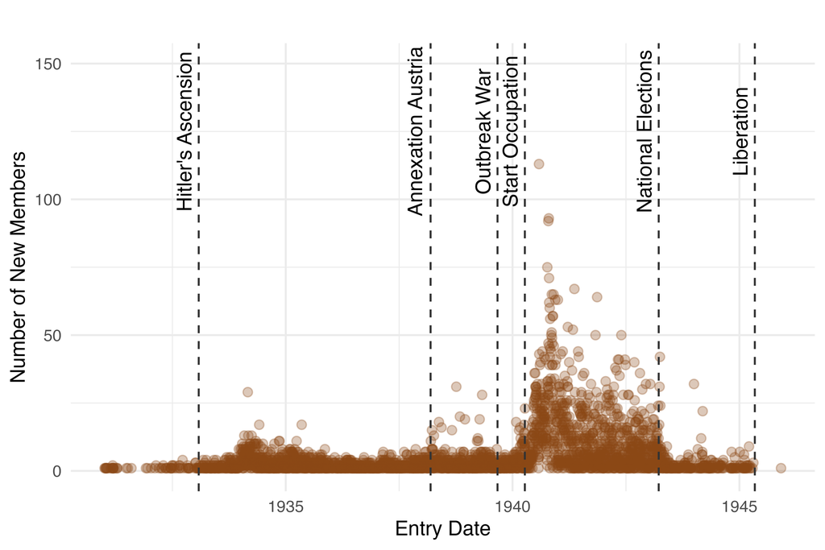

## Descriptive Results (2/3)

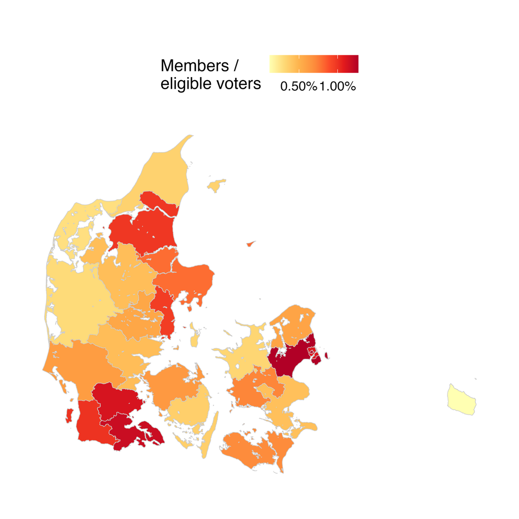

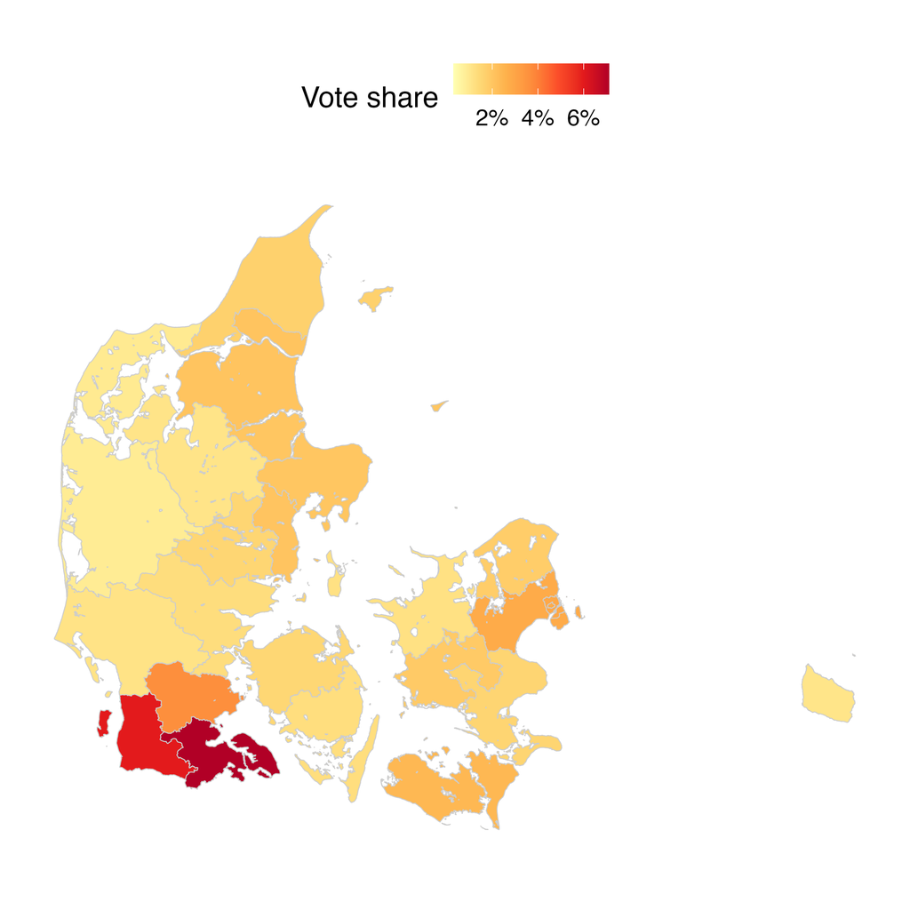

## Descriptive Results (3/3)

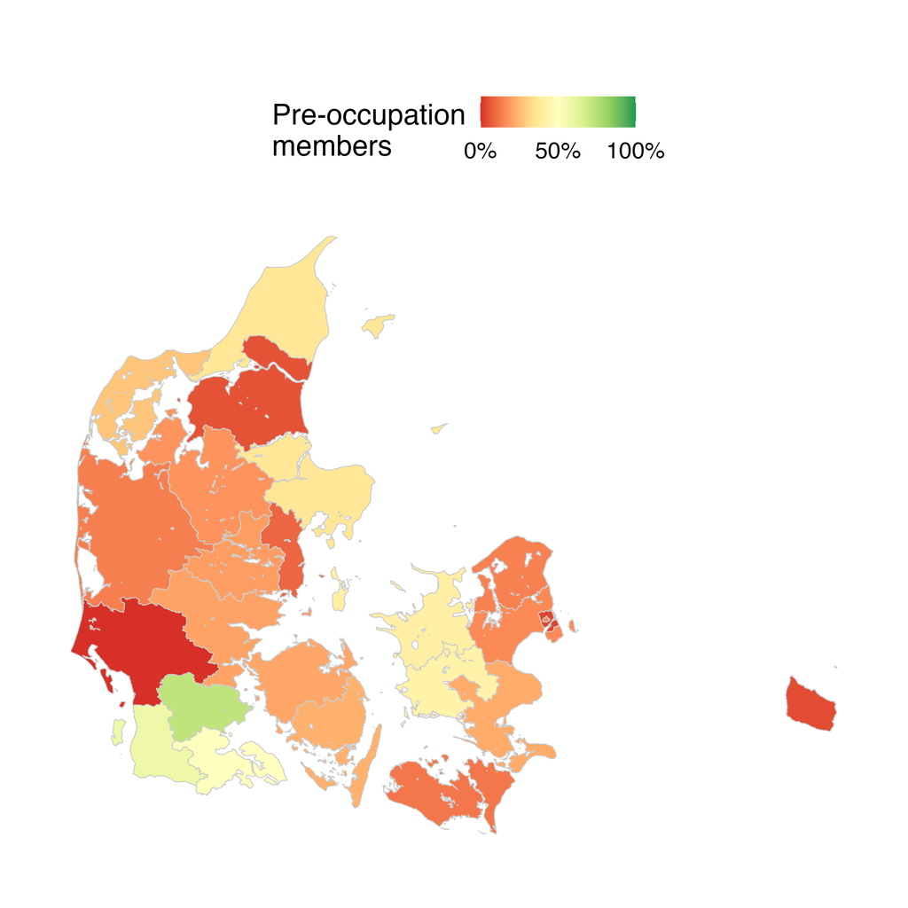

## DiD Results: Age

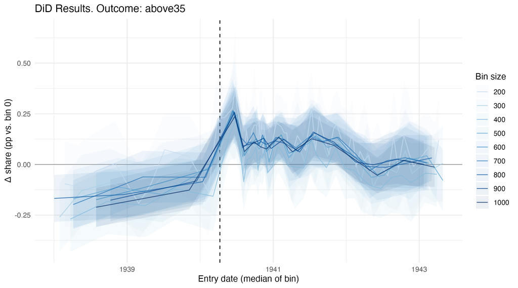

## DiD Results: Gender

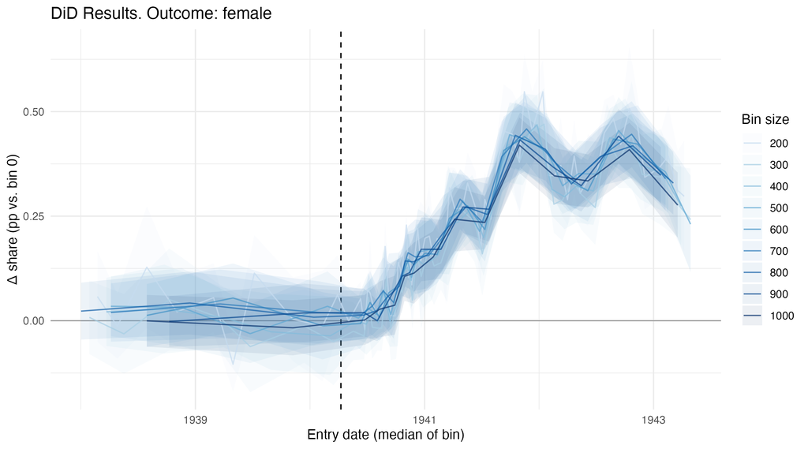

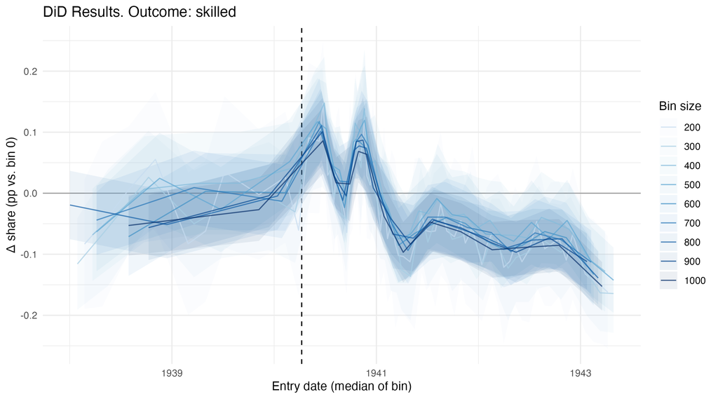

## DID Results: Civil Service

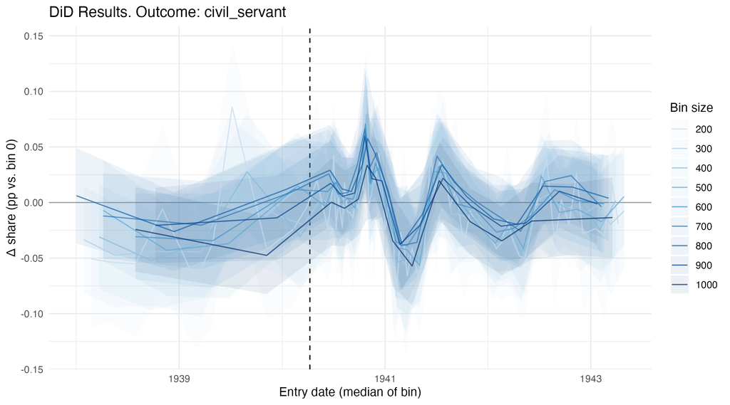

## Mechanism Test ⚙️

- `Problem`: both mechanisms predict same post-invasion joiners (older, educated, higher-class)
- `Strategy`:
  - 1943 election returns: no instrumental signal (secret ballot, post-Stalingrad)
  - Does post-invasion membership gain predict 1939/43 vote delta?
- Assumption:
  - closely predictive $\rightarrow$ preference revelation from same latent pool
  - no predictive power or negative $\rightarrow$ opportunistic joiners

## Mechanism Test ⚙️

Full sample

Excl. NS

New members post-invasion (per 100 voters)

1.302*

1.645***

(0.552)

(0.452)

DNSAP vote share 1939 (pp)

-0.276+

-0.559***

(0.164)

(0.074)

Pre-invasion membership density

2.158+

-0.536

(1.170)

(1.148)

Intercept

-0.579+

0.134

(0.344)

(0.182)

Num.Obs.

117

110

R2

0.397

0.677

R2 Adj.

0.381

0.668

- p < 0.1, * p < 0.05, ** p < 0.01, *** p < 0.001

SEs clustered at Amt level.

## Mechanism Test ⚙️

- with 1pp post-invasion increase in members $\rightarrow$ 1.6pp increase in vote share
- negative association with pre-invasion vote share $\rightarrow$ ceiling
- relationship most pronounced *outside* Northern Schleswig

`Interpretation`: *preference revelation*

- new members and later voters are drawn from the same finite pool
- areas saturated pre-invasion do not show same post-invasion dynamics

## Discussion️

- German invasion caused nationwide DNSAP surge
  - immediate spike in membership, especially among `older, skilled, educated, higher-class` individuals
  - mechanism test indicates `preference revelation` rather than opportunism
- `Historic` parallels: cooperative occupation governments in Belgium, Netherlands, Vichy France
- `Contemporary` parallels: Donbas, ISIS-held Syria/Iraq
- `Limitations`: historical records, no attitudinal data, imputation bias

# Thank you for your attention.

Questions or feedback? Reach out:

- 🌐 [frederikthieme.net](https://frederikthieme.net/)
- 📥 frederik.thieme@hu-berlin.de
- 🟦 frederikthieme.bsky.social

# References

Aaskoven, Lasse. 2022. “Foreign Occupation and Support for International Cooperation: Evidence from Denmark.” *World Politics* 74 (2): 285–325. https://doi.org/10.1017/S004388712200003X.

Aaskoven, Lasse, Christian Glaßel, and Adam Scharpf. 2025. “Military Collaboration Under Occupation: Evidence from Danish Officers During Nazi Rule.”

Berman, Eli, Jacob N Shapiro, and Joseph H Felter. 2011. “Can Hearts and Minds Be Bought? The Economics of Counterinsurgency in Iraq.” *Journal of Political Economy* 119 (4).

Cagé, Julia, Anna Dagorret, Pauline Grosjean, and Saumitra Jha. 2023. “Heroes and Villains: The Effects of Heroism on Autocratic Values and Nazi Collaboration in France.” *American Economic Review* 113 (7): 1888–1932. https://doi.org/10.1257/aer.20211509.

Fontana, Nicola, Tommaso Nannicini, and Guido Tabellini. 2023. “Historical Roots of Political Extremism: The Effects of Nazi Occupation of Italy.” *Journal of Comparative Economics* 51 (3): 723–43. https://doi.org/10.1016/j.jce.2023.05.006.

Fouka, Vasiliki, and Hans-Joachim Voth. 2023. “Collective Remembrance and Private Choice: German–Greek Conflict and Behavior in Times of Crisis.” *American Political Science Review* 117 (3): 851–70. https://doi.org/10.1017/S0003055422001095.

Hechter, Michael, and Oriol Vidal-Aparicio. 2011. “Dynamics of Military Occupation.” In *The Handbook on the Political Economy of War*. Edward Elgar Publishing.

Hickman, John. 2017. “The Occupier’s Dilemma: Problem Collaborators.” *Comparative Strategy* 36 (3): 228–40. https://doi.org/10.1080/01495933.2017.1338480.

Lyall, Jason, Yuki Shiraito, and Kosuke Imai. 2015. “Coethnic Bias and Wartime Informing.” *The Journal of Politics* 77 (3): 833–48. https://doi.org/10.1086/681590.